# Welcome!

An overview of the course

Daniel Anderson

Week 1, Class 1

# Agenda

- Getting on the same page
- Syllabus
- A little bit of git/GitHub

class: center middle inverse

# whoisyou?

.left[ * Introduce yourself * Why are you here? * What pronouns would you like us to use for you for this class? * What was one thing you did not related to academic work over winter break?]

# A more specific policy

### Kiddos in class

–

1. All breastfeeding babies are welcome in class as often as necessary.

–

2. Non-nursing babies and older children are welcome whenever alternate arrangements cannot be made. As a parent of two young children, I understand that babysitters fall through, partners have conflicting schedules, children get sick, and other issues arise that leave parents with few other options.

–

3. In cases where children come to class, I invite parents/caregivers to sit close to the door so as to more easily excuse yourself to attend to your child’s needs. Non-parents in the class: please reserve seats near the door for your parenting classmates.

–

4. All students are expected to join with me in creating a welcoming environment that is respectful of your classmates who bring children to class.

background-image: url(https://akm-img-a-in.tosshub.com/indiatoday/images/story/201802/Syllabus-featured.jpeg?rpmIvNBBqGMDT7lPG.Qe4AzWs6OfDh9K) class: inverse bottom background-size:cover

# A note on these slides

- All produced with R through R Markdown
- I’ll try to always run `knitr::purl` on the slides before class so you have the code from the slides (occassionally won’t be terrifically useful). These will be posted to Canvas.
- I’ll also always try to get a PDF of the slides up and posted to canvas.

# Learning objects for this class

- Transform data in a variety of ways to create effective data visualizations

–

- Understand and fluently apply different types of data joins

| * Understand best practices in data visualization |
| --- |

- Customize ggplot2 graphics by reordering factors, creating themes, and applying ggthemes

–

- Create an online data visualization portfolio using distill and/or flexdashboards to demonstrate key learning

# Weekly learning objectives

Provide you a frame for what you should be working to learn for that specific week.

–

### This week’s objectives

- Understand the requirements of the course
- Understand the requirements of the final project
- Be ready to go with *git* and GitHub

# Other books (also free)

.pull-left[ Bryan (http://happygitwithr.com)

[interactive chart not shown]

]

.pull-right[ Wickham & Grolemund (https://r4ds.had.co.nz)

]

class: inverse center middle # Some examples

class: inverse background-image:url(https://user-images.githubusercontent.com/25231784/41408567-08313b66-6fcb-11e8-8c55-75baa36364cd.png) background-size:contain

[Paul Campbell](https://gist.github.com/PaulC91/e767ca4f0c4335e6e0d2f71eb7cc98cc)

class: bottom background-image:url(https://static01.nyt.com/images/2018/05/02/learning/economic-mobilityLN/economic-mobilityLN-superJumbo.png?quality=90&auto=webp) background-size:contain

[Patrick Honner](https://www.nytimes.com/2018/05/03/learning/lesson-plans/moving-on-up-teaching-with-the-data-of-economic-mobility.html) via NYT

# Lab Schedule

1. GitHub collabo (**Assigned: 1/8/19**; **Due: 1/13/19**)
2. Mapping data to aesthetics (**Assigned: 1/15/19**; **Due: 1/20/19**)

   **Homework 1**
3. Visual perception (**Assigned: 1/29/19**; **Due: 2/3/19**)
4. Color (**Assigned: 2/5/19**; **Due: 2/10/19**)

   **Homework 2**
5. Tables/Uncertainty (**Assigned: 2/19/19**; **Due: 2/24/19**)

# Quick note on reproducibility

A [great blog post](https://simplystatistics.org/2019/08/28/you-can-replicate-almost-any-plot-with-ggplot2/) by [Rafael Irizarry](https://twitter.com/rafalab) shows how almost any plot you see in popular media can be reproduced in R with ggplot.

### For example

# Wall Street Journal Version

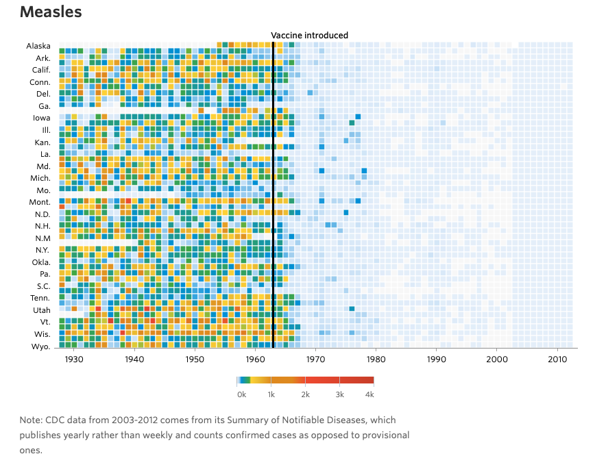

# ggplot reproduction

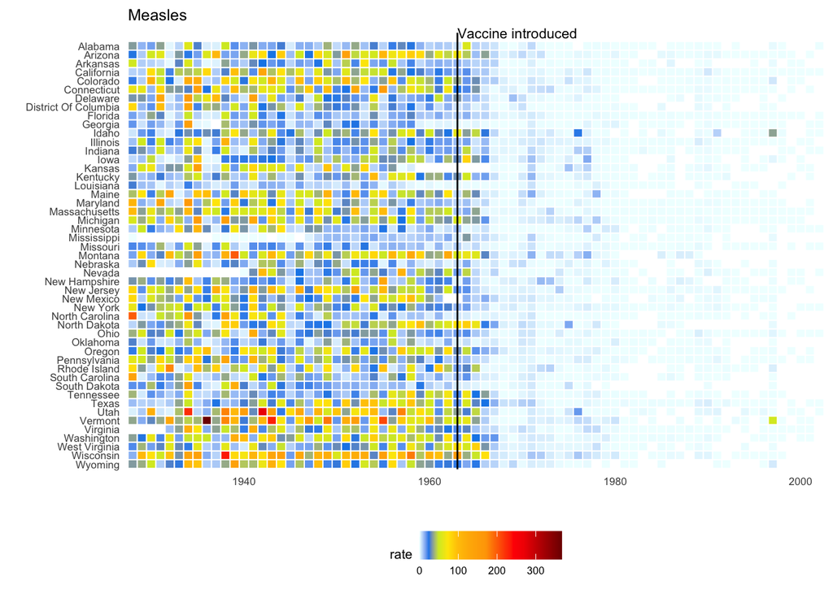

# Presentation order

.pull-left[ We’re starting a bit later than the syllabus outlines because enrollment is lower than in the past.

.gray[I’ll email this out too] ]

.pull-right[

| Date | Presenter |
| --- | --- |
| 2020-01-22 | Claire |
| 2020-01-27 | Bryce |
| 2020-01-29 | Katherine |
| 2020-02-03 | Asha |
| 2020-02-05 | Mike |
| 2020-02-10 | Joanna |
| 2020-02-12 | Thuy |
| 2020-02-17 | Stephanie |
| 2020-02-19 | Akhila |
| 2020-02-24 | Jim |
| 2020-02-26 | Brock |
| 2020-03-02 | Sophie |

]

# Product

Four components:

- A web-deployed portfolio showcasing your [#dataviz](https://twitter.com/search?q=%23DataViz&src=tyah) skills.
  - [distill](https://rstudio.github.io/distill/) (what I’ll lecture on), [R Markdown](https://bookdown.org/yihui/rmarkdown/rmarkdown-site.html), or [blogdown](https://bookdown.org/yihui/blogdown/) website
  - Technical document with pagedown or [bookdown](https://bookdown.org/yihui/bookdown/)
  - Scientific poster with pagedown
  - [flexdashboard](https://rmarkdown.rstudio.com/flexdashboard/)
- At least three finalized data displays, with each accompanied by a strong narrative/story, as well as the history of how the visualization changed over time.
- Housed on GitHub
  - Fully reproducible
- Deployed through [GitHub pages](https://pages.github.com) (or netlify or similar if you’re feeling brave)

# Draft

- Expected to still be a work in progress
  - Data visualizations should be largely complete
- Deployment not expected
- Provided to your peers so they can learn from you as much as you can learn from their feedback

# Presentation

Order randomly assigned. Basically a chance to share what you created!

- Discuss what is trying to be communicated
- Share the final products
- Discuss the progression along the way and why specific changes were made

# Grading

| **Lower percent** | **Lower point range** | **Grade** | **Upper point range** | **Upper percent** |
| --- | --- | --- | --- | --- |
| 0.97 | (194 pts) | A+ |  |  |
| 0.93 | (186 pts) | A | (194 pts) | 0.97 |
| 0.90 | (180 pts) | A- | (186 pts) | 0.93 |
| 0.87 | (174 pts) | B+ | (180 pts) | 0.90 |
| 0.83 | (166 pts) | B | (174 pts) | 0.87 |
| 0.80 | (160 pts) | B- | (166 pts) | 0.83 |
| 0.77 | (154 pts) | C+ | (160 pts) | 0.80 |
| 0.73 | (146 pts) | C | (154 pts) | 0.77 |
| 0.70 | (140 pts) | C- | (146 pts) | 0.73 |
|  |  | F | (140 pts) | 0.70 |

# 😬

I will be out .bolder[all] of week 4! * We will have a guest lecturer, Dr. [Patrick Kennedy](https://twitter.com/pkqstr) from the [Center on Teaching and Learning](https://ctl.uoregon.edu).

# Demo

- Creating a GitHub repo
- Sharing access (or creating an organization)
- Cloning the repo
- stage, commit, push
- pull
- forking and issues
- The [gitkraken](https://www.gitkraken.com) GUI

class:inverse middle center

# Next time

### Collaborating with GitHub lab